# Progress Memo 2

Final Project  
Data Science 1 with R (STAT 301-1)

Author

Hannah Ma

Published

November 29, 2023

**Github Repo Link**

https://github.com/stat301-1-2023-fall/final-project-1-Hanyuyuu

### Data Cleaning

Although my dataset came fairly complete and mostly tidy from the source, it lacked important metadata about each variable as it was stored in a `.csv` file. My cleaning of the data involved going through the dataset to find variables which would be useful to convert to into factors, logicals, and datetimes. To do so I used a series of `for` loops inspired by L11 Exercise 10.

### My progress

To begin my EDA, I borrowed code from L11 Exercise 9 to generate quick bar charts and histograms to visualize the distributions of all factor and numerical variables. My research question from the first progress memo was investigating the **primary predictors of traffic incidents in Chicago,** which I did not realize was recorded as a variable already in the dataset. Below are very rough barplots of the distribution of the primary and secondary contributory causes of crashes in the dataset:

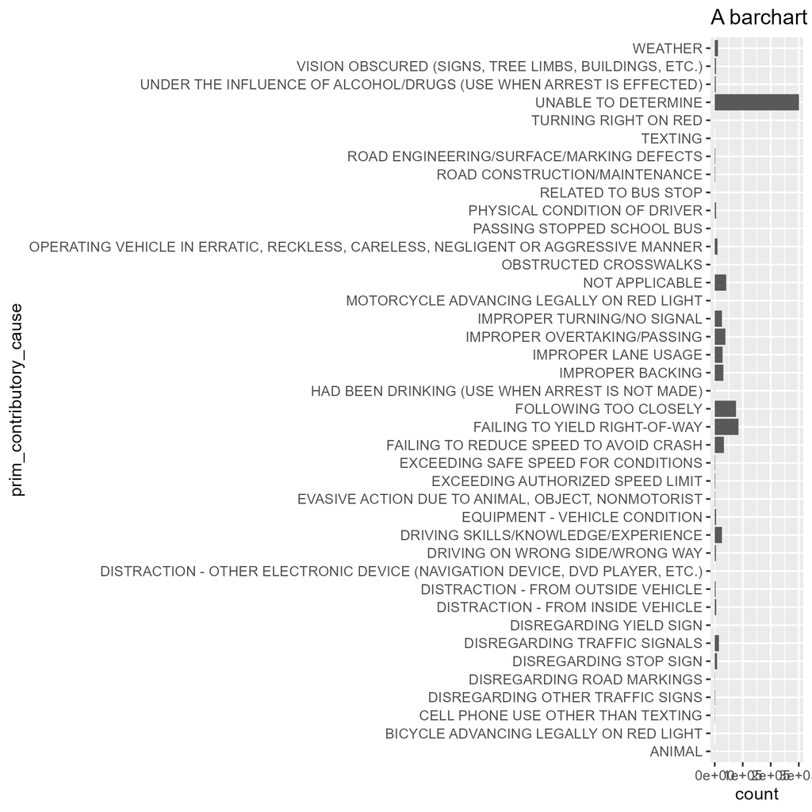

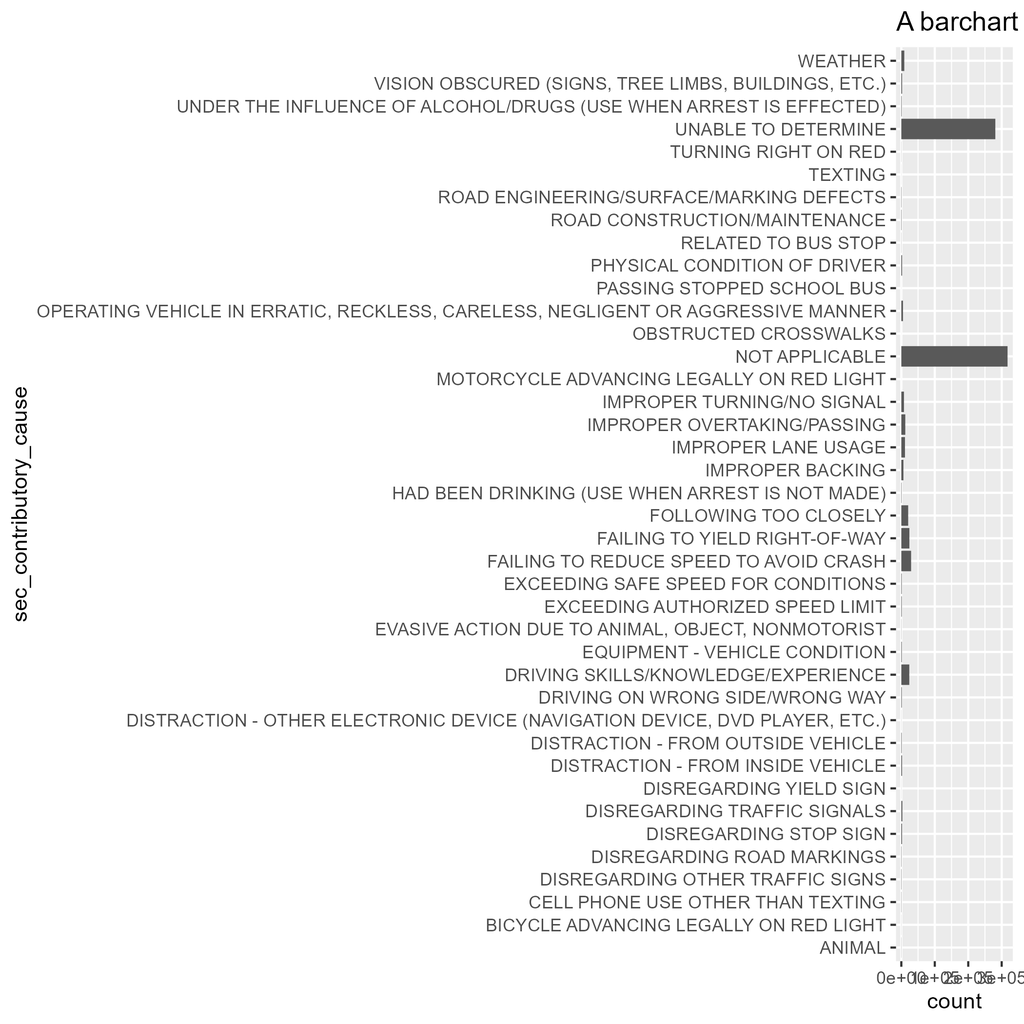

Seeing that the primary and secondary contributory causes recorded in this dataset were either not-applicable or undetermined was quite unsatisfying. The lack of unexpected results was a trend found in the distribution of lighting conditions, road defects, and most severe injury.

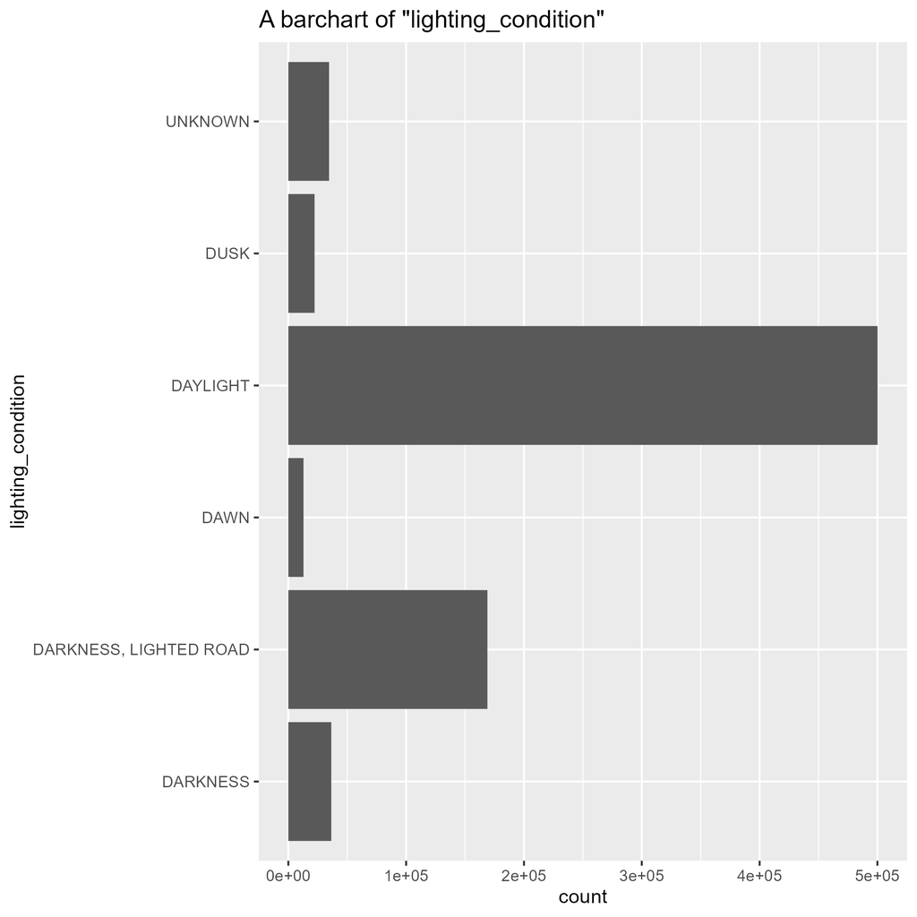

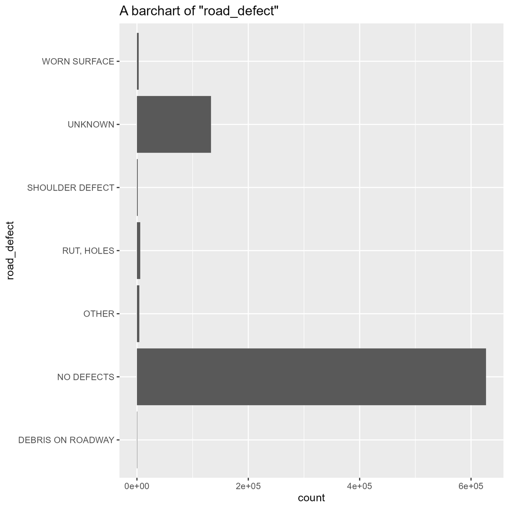

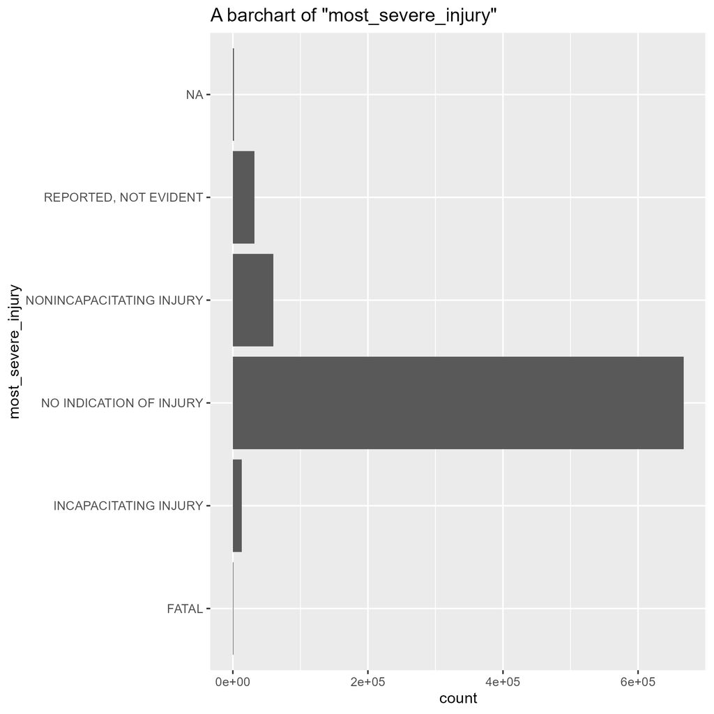

|  | posted_speed_limit | street_no | num_units | crash_hour | crash_day_of_week | crash_month | latitude | longitude | delay |
| --- | --- | --- | --- | --- | --- | --- | --- | --- | --- |
| posted_speed_limit | 1.000 | 0.018 | 0.013 | -0.039 | 0.018 | -0.034 | NA | NA | -0.101 |
| street_no | 0.018 | 1.000 | -0.064 | 0.071 | -0.012 | -0.056 | NA | NA | 0.008 |
| num_units | 0.013 | -0.064 | 1.000 | 0.091 | 0.013 | -0.010 | NA | NA | -0.040 |
| crash_hour | -0.039 | 0.071 | 0.091 | 1.000 | 0.155 | -0.063 | NA | NA | -0.051 |
| crash_day_of_week | 0.018 | -0.012 | 0.013 | 0.155 | 1.000 | 0.009 | NA | NA | 0.029 |
| crash_month | -0.034 | -0.056 | -0.010 | -0.063 | 0.009 | 1.000 | NA | NA | -0.006 |
| latitude | NA | NA | NA | NA | NA | NA | 1 | NA | NA |
| longitude | NA | NA | NA | NA | NA | NA | NA | 1 | NA |
| delay | -0.101 | 0.008 | -0.040 | -0.051 | 0.029 | -0.006 | NA | NA | 1.000 |

Such plots reveal that most crashes, fortunately, do not appear to be due to extreme weather or road conditions, and most are not incredibly serious.

Thus, I would like to change the direction of my EDA from this point onwards into investigating the **primary predictors of particular intensities of crashes**, based on the `most_severe_injury` plot above, **and particular types of crashes**, based upon the `prim_contributory_cause` plot. For example, what conditions correlate with crashes due to a failure to reduce vehicle speed? How intense, typically are these kinds of crashes? Viewing the dataset with a more specific lense may help me develop more concrete findings. One particular direction I can envision myself taking this project is looking solely at “failure to yield right-of-way” crashes. Such crashes might be due to an inability to see an oncoming car or pedestrian, and as I will be integrating map data into this project, I may be able to find certain areas where these types of crashes are concentrated, which could elucidate design faults in the roads at these areas.

### Other Interesting Findings

The only two datetime variables in this dataset record when a crash occurs and when it is reported to police, so I thought it would be interesting to subtract the two and look at delay trends. I found that within each unit of time (within a day, week, year, two years, etc.) delays are concentrated towards the beginning of that period of time, shown by the right-skewness of the plots below. However, if one looks more closely at longer periods of time, there is a curious grouping pattern which reveals that crashes are reported at “round” intervals of time (1 complete day, 2 complete days, 1 complete year, etc.) after the crash. This is particularly evident in the middle plot which shows the distribution of reporting delays throughout the week.

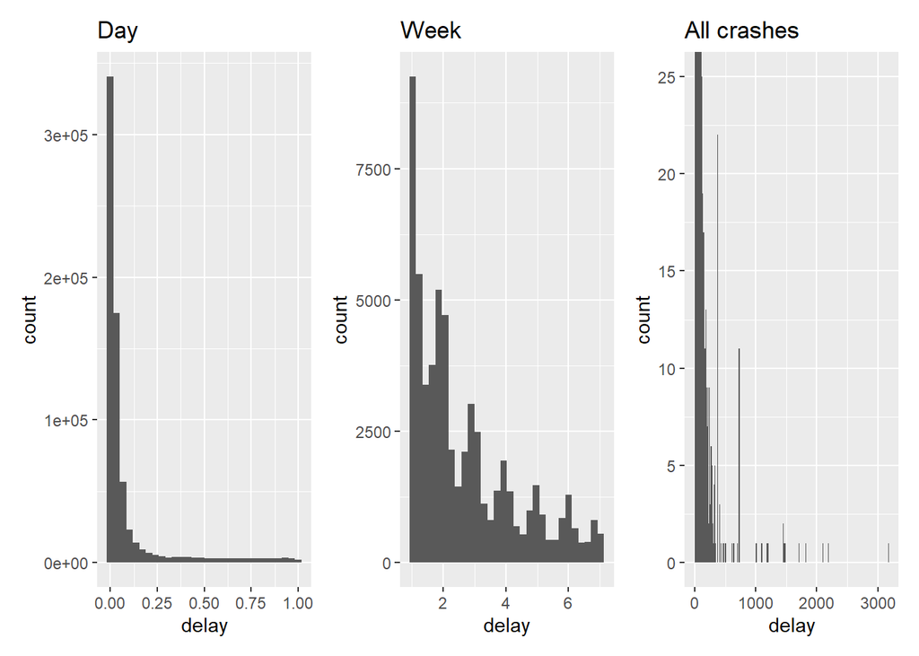

### Next Steps

My next steps are to look closer at multivariate analyses using the guiding question presented above and to work on mapping the data using the `tigris` package as I mentioned in the first memo. My guiding question for the multivariate analyses **will be what are the best predictors of different severities and types of crashes**, based on the `most_severe_injury_distribution` shown above.

I will spend some time over Thanksgiving Break to continue my analyses and joining the `tigris` data with crashes which have recorded longitudes and latitudes, and then spend reading week fine-tuning my key visualizations and the final presentation of my work. I intend to make the early-submission deadline.